# Teste_A1

Tomás Ferranti

16 April 2020

## Problema 1

1. Prepare os dados do problema para serem trabalhados em R; descreva a qua estrategia de preparacao dos dados.

Usando o comando *read.csv* especificando o *encoding*, temos nossos dados no R.

```r
data.1a <- read.csv(file = 'problema1.csv', encoding = "UTF-8", header=FALSE)
colnames(data.1a) <- c("Paciente","Sexo","Idade","TamanhoDoCistoCm","LocalizacaoDoCisto")
data.1a
```

```
##    Paciente Sexo Idade TamanhoDoCistoCm LocalizacaoDoCisto
## 1         1    F    49              6.0             cabeça
## 2         2    F    61             10.0             cabeça
## 3         3    M    34              8.2              cauda
## 4         4    F    73              3.0               colo
## 5         5    M    47              3.6             cabeça
## 6         6    M    58             10.0               colo
## 7         7    M    43              1.0             cabeça
## 8         8    M    71              1.0             cabeça
## 9         9    M    32              7.0              cauda
## 10       10    M    56              1.0             cabeça
## 11       11    M    61              6.6              corpo
## 12       12    F    49              4.0             cabeça
## 13       13    M    80              3.1              cauda
## 14       14    M    72              2.3             cabeça
## 15       15    M    47             10.5             cabeça
## 16       16    F    48              6.5              corpo
## 17       17    F    37             13.0              corpo
## 18       18    M    71              1.0               colo
## 19       19    M    74              7.0             cabeça
## 20       20    F    21             12.0              corpo
## 21       21    F    45              8.5              corpo
## 22       22    M    38             10.0               colo
```

2. Construa uma tabela e um gráfico de distribuição de freqüências para a localização do cisto no pâncreas dos pacientes;

```r
data.1b <- table(data.1a$LocalizacaoDoCisto)
data.1b
```

```
##
## cabeça  cauda   colo  corpo
##     10      3      4      5
```

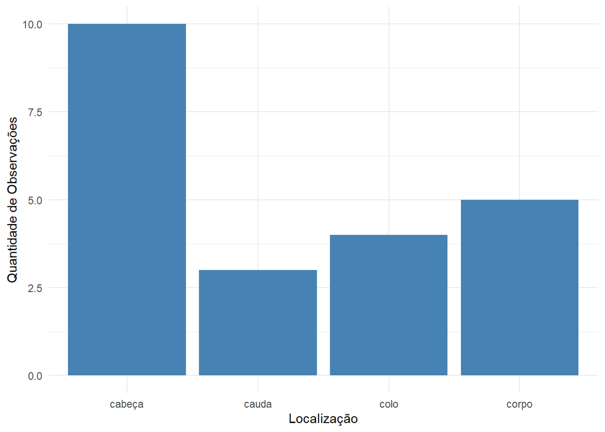

```r
ggplot(data.frame(data.1b),aes(x=Var1,y=Freq)) + geom_bar(stat="identity",fill="steelblue") + xlab("Localização") + ylab("Quantidade de Observações") + theme_minimal()
```

3. Construa uma tabela e um gráfico de distribuição de freqüências conjuntas para as variáveis sexo e localização do cisto no pâncreas. Com base na tabela e gráfico obtidos, você suspeita que exista relação entre o sexo e a localização do cisto?

```r
data.1c <- table(data.1a$Sexo,data.1a$LocalizacaoDoCisto)
data.1c
```

```
##
##     cabeça cauda colo corpo
##   F      3     0    1     4
##   M      7     3    3     1
```

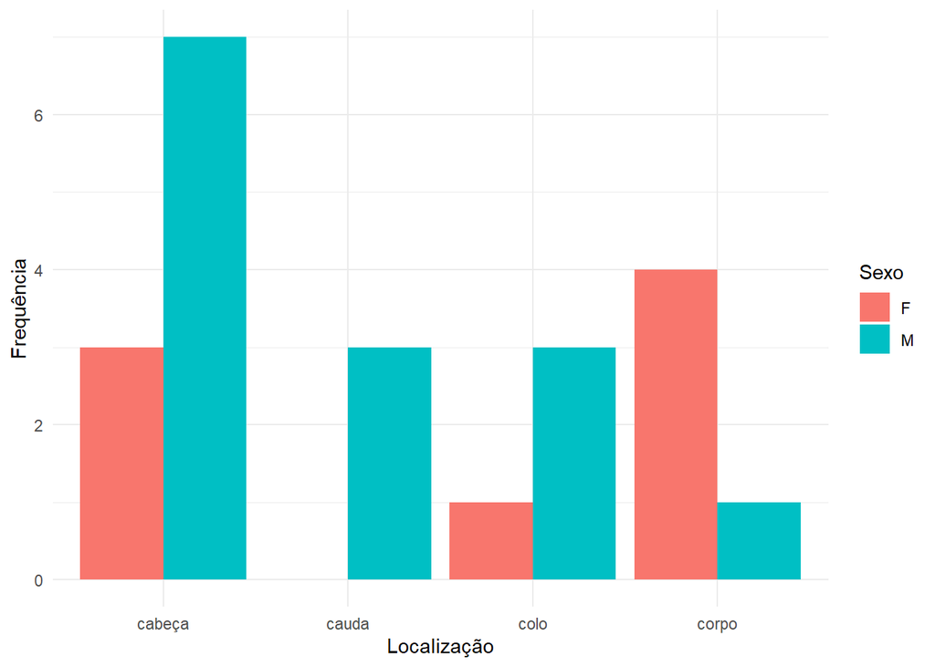

```r
data.1cDF <- data.frame(data.1c)
ggplot(data.1cDF, aes(x=Var2, y=Freq, fill=Var1)) + geom_bar(stat="identity", position = "dodge") + theme_minimal() + xlab("Localização") + ylab("Frequência") + labs(fill = "Sexo")
```

```r
x2.1c <- chisq.test(data.1c[1:2,1:4])$statistic
C.1c <- sqrt(x2.1c/(x2.1c+sum(data.1c)))
names(C.1c) <- "C"
C.1c
```

```
##         C
## 0.4696791
```

Devido ao alto valor de $C$ ($0.47$), suspeito que exista relação entre o sexo e a localização do cisto.

4. Construa uma tabela e um gráfico de distribuição de freqüências para os tamanhos dos cistos;

```r
data.1d <- table(cut(data.1a$TamanhoDoCistoCm,breaks=8))
data.1d
```

```
##
## (0.988,2.5]     (2.5,4]     (4,5.5]     (5.5,7]     (7,8.5]    (8.5,10]
##           5           4           0           5           2           3
##   (10,11.5]   (11.5,13]
##           1           2
```

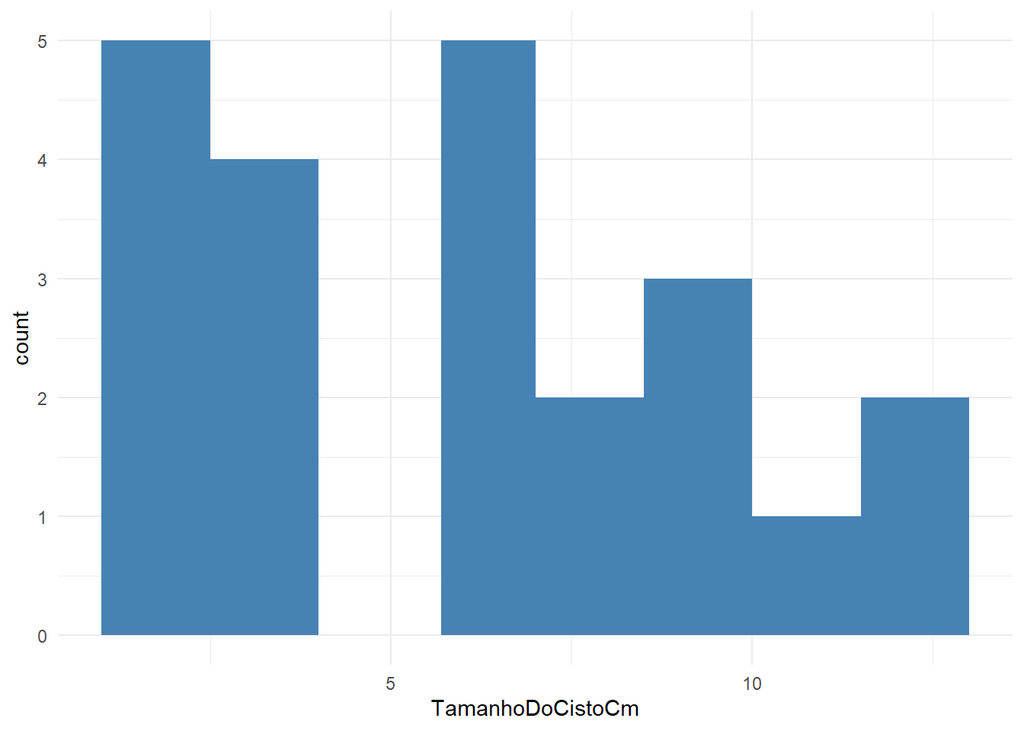

```r
ggplot(data.1a,aes(x=TamanhoDoCistoCm)) + geom_histogram(breaks=c(0.988,2.5,4,5.5,5.7,7,8.5,10,11.5,13),fill="steelblue") +theme_minimal()
```

5. Produza os graficos *boxplot* dos tamanhos dos cistos segundo o sexo dos pacientes e suas localizações no pâncreas. Interprete os gráficos apresentados.

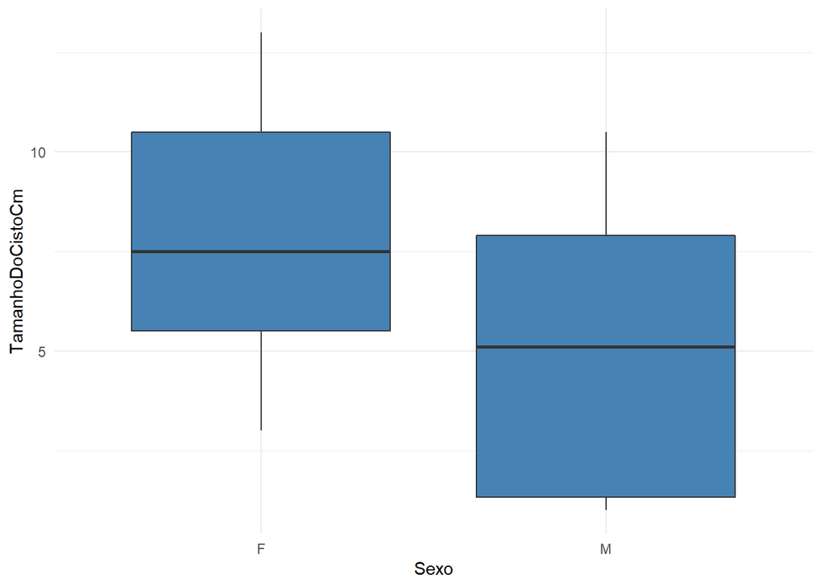

```r
ggplot(data.1a,aes(x=Sexo,y=TamanhoDoCistoCm)) + geom_boxplot(fill="steelblue") + theme_minimal()
```

Podemos perceber pelo primeiro *boxplot* que pessoas do sexo feminimo possuem um cisto de tamanho maior.

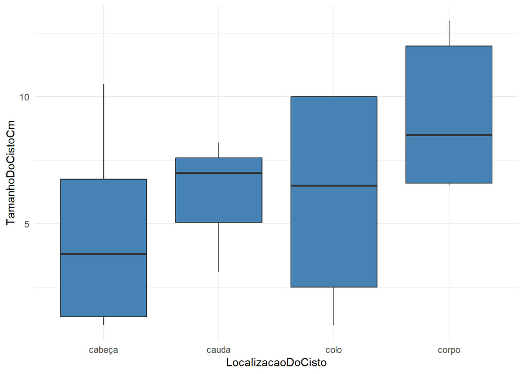

```r
ggplot(data.1a,aes(x=LocalizacaoDoCisto,y=TamanhoDoCistoCm)) + geom_boxplot(fill="steelblue") + theme_minimal()
```

Podemos perceber pelo segundo *boxplot* que cistos no corpo do pâncreas possuem um tamanho maior enquanto que, na cabeça do pâncreas, possuem um tamanho menor.

6. Construa um gráfico que permita avaliar a relação entre a idade do paciente e o tamanho do cisto. Comente o resultado.

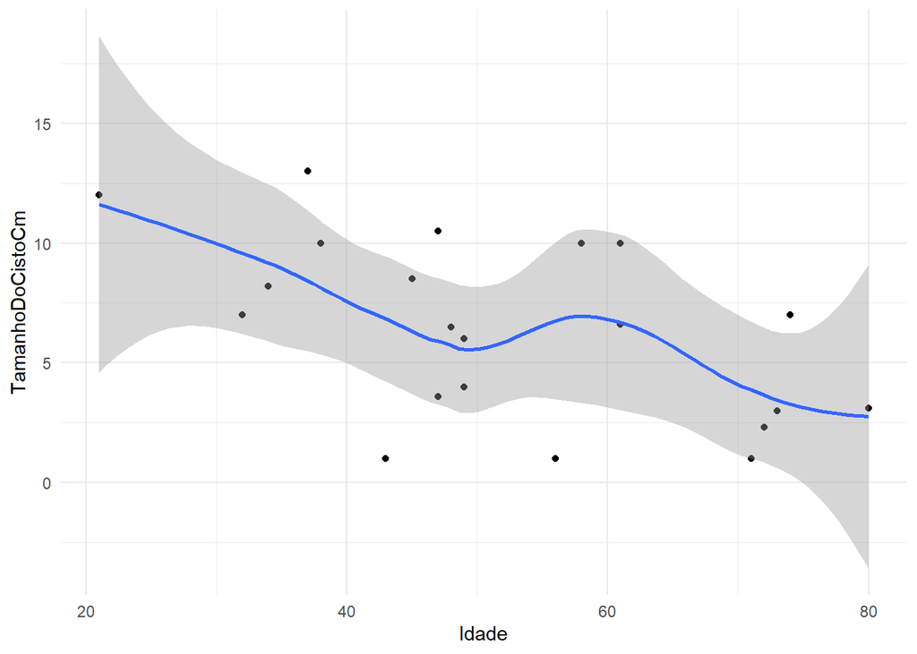

```r
ggplot(data.1a,aes(x=Idade,y=TamanhoDoCistoCm)) + geom_point(fill="steelblue") + geom_smooth() + theme_minimal()
```

Podemos perceber pelo gráfico que, para estes dados, quanto mais velha a pessoa, menor é o tamanho dos cistos.

7. Calcule as medidas de posição e dispersão estudadas para os tamanhos dos cistos. Depois, calcule-as novamente, para cada sexo. Você suspeita que exista relação entre o tamanho dos cistos e o sexo dos pacientes?

```r
data.1g.1 <- data.1a$TamanhoDoCistoCm
data.1g.2 <- data.1a[data.1a$Sexo == "M",]$TamanhoDoCistoCm
data.1g.3 <- data.1a[data.1a$Sexo == "F",]$TamanhoDoCistoCm
data.1g <- matrix(nrow=3,ncol=5)
colnames(data.1g) <- c("Média","Desvio Padrão","1º Quantil","2º Quantil","3º Quantil")
rownames(data.1g) <- c("Gerais","Masc.","Fem.")

data.1g[1,1] <- mean(data.1g.1)
data.1g[1,2] <- ((length(data.1g.1)-1)/length(data.1g.1))^(1/2)*sd(data.1g.1)
data.1g[1,3:5] <- quantile(data.1g.1,c(0.25,0.5,0.75))

data.1g[2,1] <- mean(data.1g.2)
data.1g[2,2] <- ((length(data.1g.2)-1)/length(data.1g.2))^(1/2)*sd(data.1g.2)
data.1g[2,3:5] <- quantile(data.1g.2,c(0.25,0.5,0.75))

data.1g[3,1] <- mean(data.1g.3)
data.1g[3,2] <- ((length(data.1g.3)-1)/length(data.1g.3))^(1/2)*sd(data.1g.3)
data.1g[3,3:5] <- quantile(data.1g.3,c(0.25,0.5,0.75))
data.1g
```

```
##           Média Desvio Padrão 1º Quantil 2º Quantil 3º Quantil
## Gerais 6.150000      3.737494      3.025       6.55      9.625
## Masc.  5.164286      3.561021      1.325       5.10      7.900
## Fem.   7.875000      3.398069      5.500       7.50     10.500
```

Podemos ver que os valores femininos são muito maiores do que os masculinos através da média e dos quantis, com um desvio padrão parecido. Logo, existe uma relação.

## Problema 2: Escolha_Carreira

Foi realizada uma pesquisa junto aos alunos classificados no vestibular da UFRJ em 1993. A Tabela de contingência a seguir foi montada a partir dos dados que constavam em 810 questionários por amostragem.

```r
data.2 <- matrix(c(13,24,0,11,33,81,2,1,1,0,5,9,113,176,49,61,286,685,4,2,1,0,6,13,5,5,1,1,10,22,137,208,52,73,340,810),nrow=6,ncol=6)
colnames(data.2) <- c("Mercado Trabalho","Prestígio","Aptidão Pessoal","BaixaConcPorVagas","PerpesctSalariais","Total")
rownames(data.2) <- c("Biomédica","Exatas/Tecnologia","Arquit/ArtesGraf","Geo-Economica","Outras","Total")

data.2
```

```
##                   Mercado Trabalho Prestígio Aptidão Pessoal BaixaConcPorVagas
## Biomédica                       13         2             113                 4
## Exatas/Tecnologia               24         1             176                 2
## Arquit/ArtesGraf                 0         1              49                 1
## Geo-Economica                   11         0              61                 0
## Outras                          33         5             286                 6
## Total                           81         9             685                13
##                   PerpesctSalariais Total
## Biomédica                         5   137
## Exatas/Tecnologia                 5   208
## Arquit/ArtesGraf                  1    52
## Geo-Economica                     1    73
## Outras                           10   340
## Total                            22   810
```

**(a)** Com base nessa tabela de contingência obtenha uma nova tabela com percentuais:

- Promovendo eventualmente algumas fusões de linhas ou colunas de modo a garantir a confiabilidade do processo de extrapolação dos resultados da amostra para a população;

As fusões realizadas foram a de juntar Arquit/ArtesGraf com Geo-Economica (Humanas), junção das colunas Mercado Trabalho, BaixaConcPorvagas e PerpesctSalariais em uma só (Mercado Trabalho) e junção de Prestígio e Aptidão Pessoal em uma só (Aptidão Pessoal). Segue a nova tabela abaixo:

```r
data.2a.1 <- data.2
data.2a.1[3,] <- data.2a.1[3,]+data.2a.1[4,]
data.2a.1 <- data.2a.1[c(1,2,3,5,6),]
rownames(data.2a.1)[3] <- "Humanas"
data.2a.2 <- data.2a.1[,c(1,3)]
data.2a.2[,1] <- data.2a.2[,1] + data.2a.1[,4] + data.2a.1[,5]
data.2a.2[,2] <- data.2a.2[,2] + data.2a.1[,2]
data.2a.2 <- cbind(data.2a.2, Total = data.2a.2[,1] + data.2a.2[,2])
data.2a.2
```

```
##                   Mercado Trabalho Aptidão Pessoal Total
## Biomédica                       22             115   137
## Exatas/Tecnologia               31             177   208
## Humanas                         14             111   125
## Outras                          49             291   340
## Total                          116             694   810
```

- Comparando as 5 áreas de opções de carreira em termos do perfil de motivações para as escolhas características de cada área.

```r
data.2b <- data.2a.2
data.2b[,1] <- data.2b[,1]/data.2b[5,1]
data.2b[,2] <- data.2b[,2]/data.2b[5,2]
data.2b[,3] <- data.2b[,3]/data.2b[5,3]
data.2b
```

```
##                   Mercado Trabalho Aptidão Pessoal     Total
## Biomédica                0.1896552       0.1657061 0.1691358
## Exatas/Tecnologia        0.2672414       0.2550432 0.2567901
## Humanas                  0.1206897       0.1599424 0.1543210
## Outras                   0.4224138       0.4193084 0.4197531
## Total                    1.0000000       1.0000000 1.0000000
```

**(b)** Extraia as conclusões cabíveis.

```r
x2.2b <- chisq.test(data.2a.2[1:4,1:2])$statistic
C.2b <- sqrt(x2.2b/(x2.2b+data.2a.2[5,3]))
names(C.2b) <- "C"
C.2b
```

```
##          C
## 0.04137809
```

Dado que $C=0.0413$, temos que o grau de dependência entre as áreas é baixo. Portanto, para as áreas de Biomédica, Exatas/Tecnologia e Humanas, temos que o motivo de ingresso é relativamente o mesmo.